# Using surveil for public health research

This vignette demonstrates basic usage of *surveil* for public health research. The package is designed for routine time trend analysis, namely for time trends in disease incidence rates or mortality rates. Models were built using the [Stan](https://mc-stan.org/) modeling language for Bayesian inference with Markov chain Monte Carlo (MCMC), but users only need to be familiar with the R language.

The package also contains special methods for age-standardization, printing and plotting model results, and for measuring and visualizing health inequalities. For age-standardization see `vignette("age-standardization")`. For discussion and demonstration analysis see Donegan, Hughes, and Lee (2022).

## Getting started

```r
library(surveil)
library(ggplot2)
library(knitr)
```

To use the models provided by *surveil,* the surveillance data minimally must contain case counts, population at risk estimates, and a discrete time period variable. The data may also include one or more grouping variables, such as race-ethnicity. Time periods should consist of equally spaced intervals.

This vignette analyzes colorectal cancer incidence data by race-ethnicity, year, and Texas MSA for ages 50-79 (data obtained from CDC Wonder). The race-ethnicity grouping includes (non-Hispanic) black, (non-Hispanic) white, and Hispanic, and the MSAs include those centered on the cities of Austin, Dallas, Houston, and San Antonio.

```r
head(msa) |>
  kable(booktabs = TRUE,
        caption = "Glimpse of colorectal cancer incidence data (CDC Wonder)")
```

Glimpse of colorectal cancer incidence data (CDC Wonder)

| Year | Race | MSA | Count | Population |
| --- | --- | --- | --- | --- |
| 1999 | Black or African American | Austin-Round Rock, TX | 28 | 14421 |
| 2000 | Black or African American | Austin-Round Rock, TX | 16 | 15215 |
| 2001 | Black or African American | Austin-Round Rock, TX | 22 | 16000 |
| 2002 | Black or African American | Austin-Round Rock, TX | 24 | 16694 |
| 2003 | Black or African American | Austin-Round Rock, TX | 34 | 17513 |
| 2004 | Black or African American | Austin-Round Rock, TX | 26 | 18429 |

The primary function in *surveil* is `stan_rw`, which fits random walk models to surveillance data. The function is expects the user to provide a `data.frame` with specific column names. There must be one column named `Count` containing case counts, and another column named `Population`, containing the sizes of the populations at risk. The user must provide the name of the column containing the time period (the default is `time = Year`, to match CDC Wonder data). Optionally, one can provide a grouping factor. For the MSA data printed above, the grouping column is Race and the time column is Year.

## Preparing the data

We will demonstrate using aggregated CRC cases across Texas’s top four MSAs. The `msa` data from CDC Wonder already has the necessary format (column names and contents), but these data are dis-aggregated by MSA. So for this analysis, we first group the data by year and race, and then combine cases across MSAs.

The following code chunk aggregates the data by year and race-ethnicity:

```r
msa2 <- aggregate(cbind(Count, Population) ~ Year + Race, data = msa, FUN = sum)
```

The following code provides a glimpse of the aggregated data:

```r
head(msa2) |>
  kable(booktabs = TRUE,
        caption = "Glimpse of aggregated Texas metropolitan CRC cases, by race and year")
```

Glimpse of aggregated Texas metropolitan CRC cases, by race and year

| Year | Race | Count | Population |
| --- | --- | --- | --- |
| 1999 | Black or African American | 471 | 270430 |
| 2000 | Black or African American | 455 | 283280 |
| 2001 | Black or African American | 505 | 298287 |
| 2002 | Black or African American | 539 | 313133 |
| 2003 | Black or African American | 546 | 329481 |
| 2004 | Black or African American | 602 | 346886 |

## Model specification

### The basics

The base *surveil* model is specified as follows. The Poisson model is used as the likelihood: the probability of observing a given number of cases, $y_t$, conditional on a given level of risk, $e^{\phi_t}$, and known population at risk, $p_t$, is:
$$y_t \sim \text{Pois}(p_t \cdot e^{\phi_t})$$
where $t$ indexes the time period.

Next, we need a model for the log-rates, ${\phi_t}$. The first-difference prior states that our expectation for the log-rate at any time is its previous value, and we assign a normal probability distribution to deviations from the previous value (Clayton 1996). This is also known as the random-walk prior:
$$\phi_t \sim \text{Gau}(\phi_{t-1}, \tau^2)$$
This places higher probability on a smooth trend through time, specifically implying that underlying disease risk tends to have less variation than crude incidence.

The log-risk for time $t=1$ has no previous value to anchor its expectation; thus, we assign a prior probability distribution directly to $\phi_1$. For this prior, *surveil* uses a normal distribution. The scale parameter, $\tau$, also requires a prior distribution, and again *surveil* uses a normal model which is diffuse relative to the log incidence rates.

### Binomial model

In addition to the Poisson model, the binomial model is also available:
$$y_t \sim \text{Binom}(p_t \cdot g^{-1}(\phi_t))$$
where $g$ is the logit function and $g^{-1}(x) = \frac{exp(x)}{1 + exp(x)}$ (the inverse-logit function). If the binomial model is used the rest of the model remains the same as stated above. The Poisson model is typically preferred for rare events (such as rates below .01), otherwise the binomial model is usually more appropriate. The remainder of this vignette will proceed using the Poisson model only.

## Fitting the model

The time series model is fit by passing surveillance data to the `stan_rw` function. Here, `Year` and `Race` indicate the appropriate time and grouping columns in the `msa2` data frame.

```r
fit <- stan_rw(msa2, time = Year, group = Race, iter = 1e3)
```

```
#> Distribution: normal
#> Distribution: normal
#> Warning: Bulk Effective Samples Size (ESS) is too low, indicating posterior means and medians may be unreliable.
#> Running the chains for more iterations may help. See
#> https://mc-stan.org/misc/warnings.html#bulk-ess
#> [1] "Setting normal prior(s) for eta_1: "
#>  location scale
#>        -6     5
#> [1] "\nSetting half-normal prior for sigma: "
#>  location scale
#>         0     1
#>
#>
#>
#>
```

The `iter = 1e3` line controls how long the MCMC sampling continues for (in this case, 1,000 samples: 500 warmup, then 500 more for inference). The default is 3,000, which is more than sufficient for this example model. By default, there are four independent MCMC chains each with 500 post-warmup samples (for a total of 2,000 MCMC samples used for the estimates).

To speed things up, we could take advantage of parallel processing using the `cores` argument (e.g., add `cores = 4`) to run on 4 cores simultaneously. You can suppress the messages seen above by adding `refresh = 0`.

## Printing results

The `print` method will print the estimates with 95% credible intervals to the console; adding `scale = 100e3` will display rates per 100,000:

```r
print(fit, scale = 100e3)
```

```
#> Summary of surveil model results
#> Time periods: 19
#> Grouping variable: Race
#> Correlation matrix: FALSE
#>    time                      Race      mean   lwr_2.5  upr_97.5
#> 1  1999 Black or African American 169.96088 158.40367 182.60670
#> 2  2000 Black or African American 166.26805 156.53484 176.40527
#> 3  2001 Black or African American 168.25321 159.24234 178.17030
#> 4  2002 Black or African American 169.24999 159.88014 179.56828
#> 5  2003 Black or African American 167.05284 157.81797 176.58054
#> 6  2004 Black or African American 166.78396 157.64550 176.96209
#> 7  2005 Black or African American 159.05227 150.51078 168.26660
#> 8  2006 Black or African American 154.58917 145.83455 163.05728
#> 9  2007 Black or African American 152.61466 144.19685 161.04856
#> 10 2008 Black or African American 149.68144 142.25264 158.01461
```

[output cut: 47 more lines]

This information is also stored in a data frame, `fit$summary`:

```r
head(fit$summary)
```

```
#>   time        mean     lwr_2.5    upr_97.5                      Race Year Count
#> 1 1999 0.001699609 0.001584037 0.001826067 Black or African American 1999   471
#> 2 2000 0.001662680 0.001565348 0.001764053 Black or African American 2000   455
#> 3 2001 0.001682532 0.001592423 0.001781703 Black or African American 2001   505
#> 4 2002 0.001692500 0.001598801 0.001795683 Black or African American 2002   539
#> 5 2003 0.001670528 0.001578180 0.001765805 Black or African American 2003   546
#> 6 2004 0.001667840 0.001576455 0.001769621 Black or African American 2004   602
#>   Population       Crude
#> 1     270430 0.001741671
#> 2     283280 0.001606185
#> 3     298287 0.001693000
#> 4     313133 0.001721313
#> 5     329481 0.001657152
#> 6     346886 0.001735440
```

The `fit$summary` object can be used to create custom plots and tables.

## Visualizing results

If we call `plot` on a fitted *surveil* model, we get a `ggplot` object depicting risk estimates with 95% credible intervals:

```
#> Plotted rates are per 100,000
```

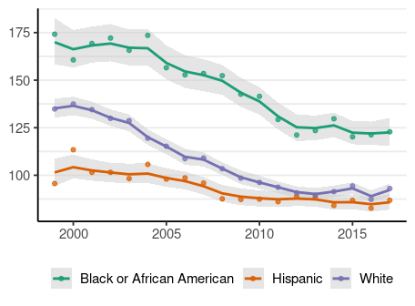

```r
plot(fit, scale = 100e3)
```

The crude incidence rates (observed values) are also plotted here as points.

The `plot` method has a number of optional arguments that control its appearance. For example, the `base_size` argument controls the size of labels. The size of the points for the crude rates can be adjusted using `size`, and `size = 0` removes them altogether. We can also use `ggplot` to add custom modifications:

```r
fig <- plot(fit, scale = 100e3, base_size = 11, size = 0)
```

```
#> Plotted rates are per 100,000
```

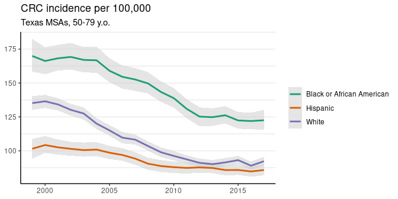

```r
fig +
  theme(legend.position = "right") +
  labs(title = "CRC incidence per 100,000",
       subtitle = "Texas MSAs, 50-79 y.o.")
```

The plot method has a `style` argument that controls how uncertainty is represented. The default, `style = "mean_qi"`, shows the mean of the posterior distribution as the estimate and adds shading to depict the 95% credible interval (as above). The alternative, `style = "lines"`, plots MCMC samples from the joint probability distribution for the estimates:

```
#> Plotted rates are per 100,000
```

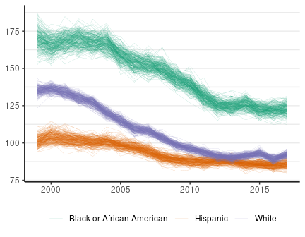

```r
plot(fit, scale = 100e3, base_size = 11, style = "lines")
```

By default, `M = 250` samples are plotted. The `style` option is available for all of the *surveil* plot methods. This style is sometimes helpful for visualizing multiple groups when their credible intervals overlap.

## Percent change

The `apc` method calculates percent change by period and cumulatively over time:

```r
fit_pc <- apc(fit)
```

The object returned by `apc` contains two data frames. The first contains estimates of percent change from the previous period:

```r
head(fit_pc$apc)
```

```
#>   time                     group        apc       lwr      upr
#> 1 1999 Black or African American  0.0000000  0.000000 0.000000
#> 2 2000 Black or African American -2.0937226 -9.480724 5.272634
#> 3 2001 Black or African American  1.2614803 -5.120038 9.241161
#> 4 2002 Black or African American  0.6447464 -5.606973 7.421085
#> 5 2003 Black or African American -1.2377383 -7.919808 5.945582
#> 6 2004 Black or African American -0.1086101 -6.239135 6.715926
```

Those estimates typically have high uncertainty.

The second data frame contains estimates of cumulative percent change (since the first observed period):

```r
head(fit_pc$cpc)
```

```
#>   time                     group        cpc       lwr      upr
#> 1 1999 Black or African American  0.0000000  0.000000 0.000000
#> 2 2000 Black or African American -2.0937226 -9.480724 5.272634
#> 3 2001 Black or African American -0.8970656 -8.852348 7.320711
#> 4 2002 Black or African American -0.3020233 -8.826111 8.530012
#> 5 2003 Black or African American -1.5948338 -9.968948 6.951389
#> 6 2004 Black or African American -1.7553448 -9.874347 7.310530
```

Each value in the `cpc` column is an estimate of the difference in incidence rates between that year and the first year (in this case, 1999) expressed as a percent of the first year’s rate. The `lwr` and `upr` columns are the lower and upper bounds of the 95% credible intervals for the estimates.

This information can also be plotted:

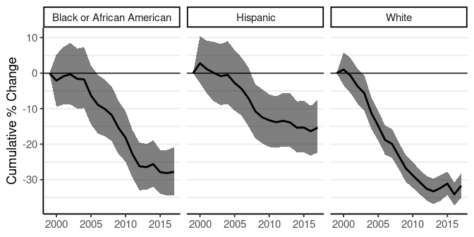

```r
plot(fit_pc, cumulative = TRUE)
```

If desired, the average annual percent change from the first period can be calculated by dividing the cumulative percent change (CPC) by the appropriate number of periods. For example, the CPC from 1999 to 2017 for whites is about -31 for an average annual percent change of about $-31/18 = -1.72$. The credible intervals for the average annual percent change can also be obtained from the CPC table using the same method. For this example, the correct denominator is $2017-1999=18$ (generally: the last year minus the first year).

## MCMC diagnostics

If you do not see any warnings printed to the R console at the end of the model fitting process then you can simply move forward with the analysis. If there is a warning, it may say that the effective sample size is low or that the R-hat values are large. For a crash course on MCMC analysis with *surveil*, including MCMC diagnostics, see the vignette on the topic `vignette("surveil-mcmc")`.

A quick and dirty summary is that you want to watch two key diagnostics, which are effective MCMC sample size (ESS) and R-hat. For all your parameters of interest, ESS should be at least 400 or so. If you want to increase the ESS, use the `iter` argument to draw more samples. The R-hat values should all be pretty near to one, such as within the range $1 \pm .02$. For the simple models we are using here, large R-hat values can often be fixed just by drawing more samples.

You can find these diagnostics by printing results `print(fit$samples)` and seeing the columns `n_eff` (for ESS) and `Rhat`.

The MCMC sampling is generally fast and without trouble when the numbers are not too small (as in this example model). When the incidence rates are based on small numbers (like counts less than 20), the sampling often proceeds more slowly and a higher `iter` value may be needed.

## Multiple time series

In most applications, the base model specification described above will be entirely sufficient. However, *surveil* provides an option for users to add a correlation structure to the model when multiple groups are modeled together. For correlated trends, this can increase the precision of estimates.

The log-rates for $k$ populations, $\boldsymbol \phi_t$, are assigned a multivariate normal distribution (Brandt and Williams 2007):
$$\boldsymbol \phi_t \sim \text{Gau}(\boldsymbol \phi_{t-1}, \boldsymbol \Sigma),$$
where $\boldsymbol \Sigma$ is a $k \times k$ covariance matrix.

The covariance matrix can be decomposed into a diagonal matrix containing scale parameters for each variable, $\boldsymbol \Delta = diag(\tau_1,\dots \tau_k)$, and a symmetric correlation matrix, $\boldsymbol \Omega$ (Stan Development Team 2021):
$$\boldsymbol \Sigma = \boldsymbol \Delta \boldsymbol \Omega \boldsymbol \Delta$$
When the correlation structure is added to the model, then a prior distribution is also required for the correlation matrix. *surveil* uses the LKJ model, which has a single shape parameter, $\eta$ (Stan Development Team 2021). If $\eta=1$, the LKJ model will place uniform prior probability on any $k \times k$ correlation matrix; as $\eta$ increases from one, it expresses ever greater skepticism towards large correlations. When $\eta <1$, the LKJ model becomes ‘concave’—expressing skepticism towards correlations of zero.

If we wanted to add a correlation structure to the model, we would add `cor = TRUE` to `stan_rw`, as in:

```r
fit <- stan_rw(msa2, time = Year, group = Race, cor = TRUE)
```

## References

Brandt, P, and JT Williams. 2007. *Multiple Time Series Models*. Sage.

Clayton, DG. 1996. “Generalized Linear Mixed Models.” In *Markov Chain Monte Carlo in Practice: Interdisciplinary Statistics*, edited by WR Gilks, S Richardson, and DJ Spiegelhalter, 275–302. CRC Press.

Donegan, Connor, Amy E. Hughes, and Simon J. Craddock Lee. 2022. “Colorectal Cancer Incidence, Inequality, and Prevention Priorities in Urban Texas: Surveillance Study with the ‘Surveil’ Software Pakcage.” *JMIR Public Health & Surveillance* 8 (8): e34589. https://doi.org/10.2196/34589.

Stan Development Team. 2021. *Stan Modeling Language Users Guide and Reference Manual, 2.28*. https://mc-stan.org.